# 14.3

Nikhil Gopal

2/8/2022

```r
rm(list = ls())
library(rstanarm)
library(tidyverse)
```

**14.3**

Graphing logistic regressions: The well-switching data described in Section 13.7 are in the folder Arsenic

A:

Fit a logistic regression for the probability of switching using log (distance to nearest safe well) as a predictor.

```r
wells$dist100 <- wells$dist/100

fit_1 <- stan_glm(formula = switch ~ log(dist), family=binomial(link="logit"),
          data=wells)
print(fit_1)
```

```
## stan_glm
##  family:       binomial [logit]
##  formula:      switch ~ log(dist)
##  observations: 3020
##  predictors:   2
## ------
##             Median MAD_SD
## (Intercept)  1.0    0.2
## log(dist)   -0.2    0.0
##
## ------
## * For help interpreting the printed output see ?print.stanreg
## * For info on the priors used see ?prior_summary.stanreg
```

B:

Make a graph similar to Figure 13.8b displaying Pr(switch) as a function of distance to nearest safe well, along with the data.

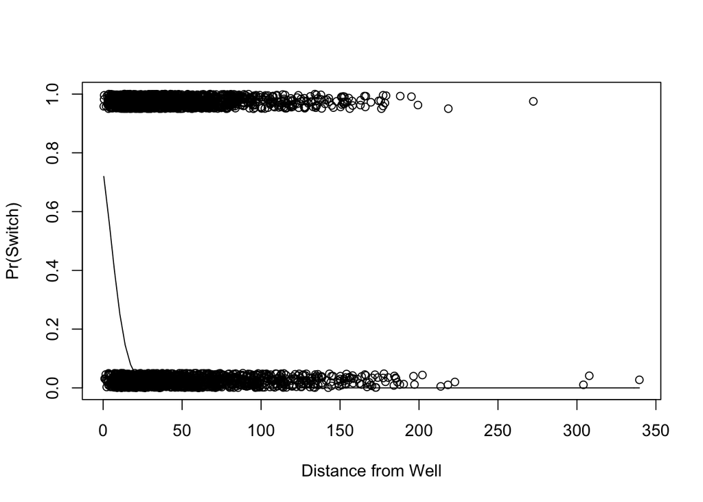

```r
#code from p 252 in text
jitter_binary <- function(a, jitt=0.05){
ifelse(a==0, runif(length(a), 0, jitt), runif(length(a), 1 - jitt, 1))
}

wells$switch_jitter <- jitter_binary(wells$switch)
plot(wells$dist, wells$switch_jitter, xlab = "Distance from Well", ylab = "Pr(Switch)")
curve(invlogit(coef(fit_1)[1] + coef(fit_1)[2]*x), add=TRUE)
```

C:

Make a residual plot and binned residual plot as in Figure 14.8.

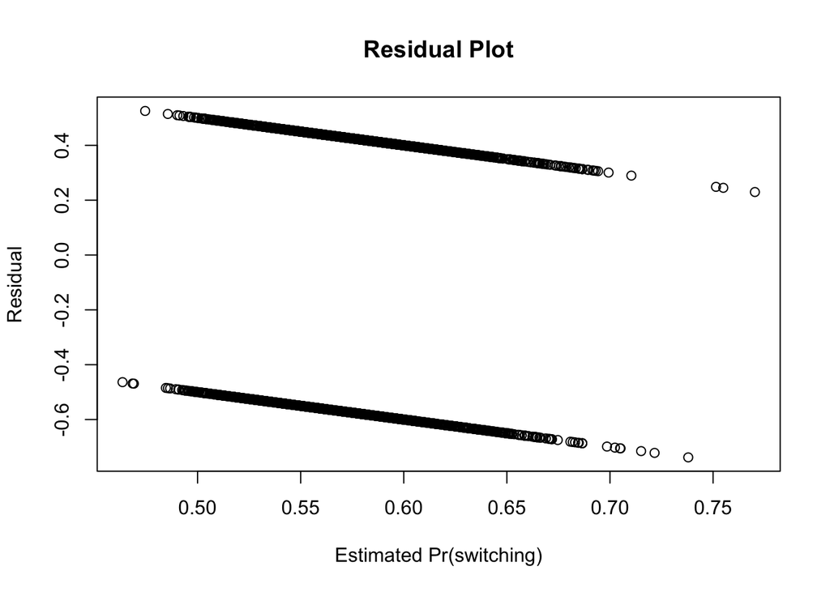

```r
#Residual plot
plot(fit_1$fitted.values, fit_1$residuals, main = "Residual Plot",
     xlab = "Estimated Pr(switching)", ylab = "Residual")
```

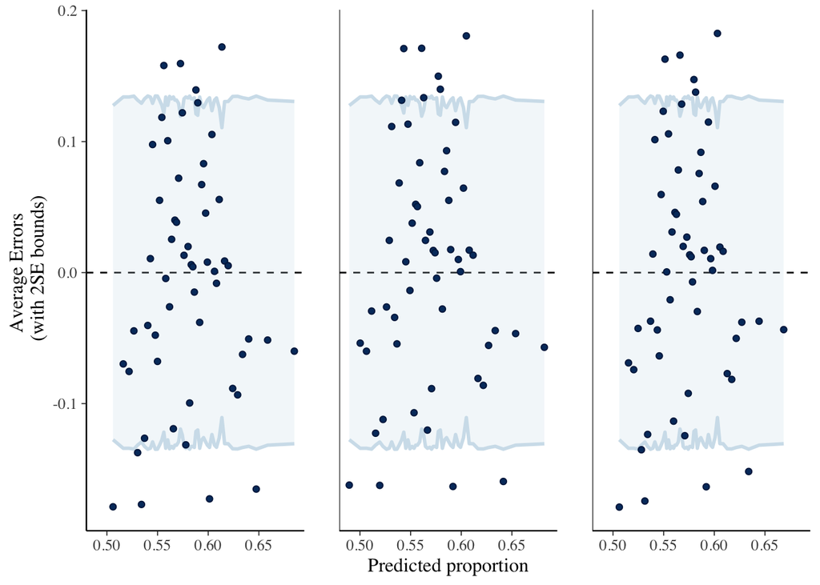

```r
#using rstanarm library
pp_check(fit_1, plotfun = "error_binned")
```

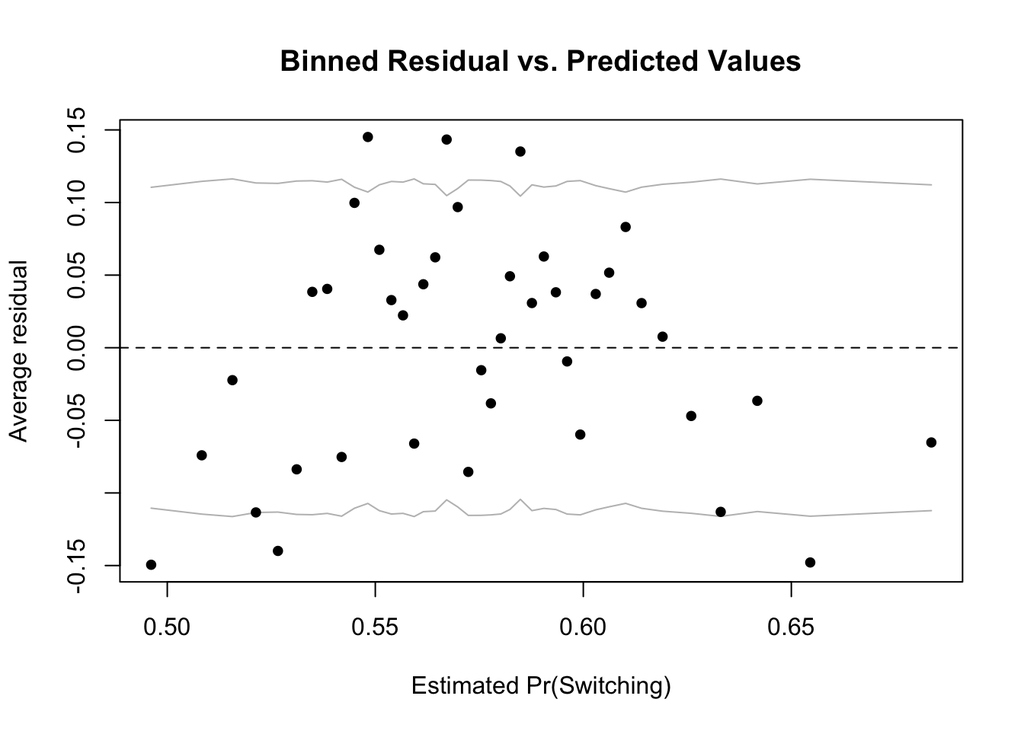

```r
#using arm (https://rdrr.io/cran/arm/man/binnedplot.html), more like book graph
arm::binnedplot(x = fit_1$fitted.values, fit_1$residuals,
                xlab = "Estimated Pr(Switching)",
                main = "Binned Residual vs. Predicted Values",
                col.int = "gray", nclass = 40)
```

D:

Compute the error rate of the fitted model and compare to the error rate of the null model.

```r
#calculate predictions
wells$predicted <- predict(fit_1, newdata = wells, type = "response")

#fit null model
null_model <- stan_glm(formula = switch ~ 1, family=binomial(link="logit"),
          data=wells)
#code from p 273 to compute error rate of models
error_rate_fit <- mean((wells$predicted>0.5 & wells$switch==0) | (wells$predicted<0.5 & wells$switch==1))

#We can compare it to the error rate of the null model, which is simply to assign the same probability to each yi. This is simply logistic regression with only a constant term, and the estimated probability will simply be the proportion of 1’s in the data, or p = n i=1 yi/n (recalling that each yi = 0 or 1). The error rate of the null model is then p or 1−p, whichever is lower

prop_1_in_data <- table(wells$switch)

prop_1_in_data <- 1737/3020

error_rate_null <- 1 - prop_1_in_data

df <- data.frame(
  "model" <- c("Fitted", "Null"),
  "error" <- c(error_rate_fit, error_rate_null))

colnames(df) <- c("model", "error")

print(paste("Fitted model error: ", round(error_rate_fit, 3)))
```

```
## [1] "Fitted model error:  0.419"
```

```r
print(paste("Null model error: ", round(error_rate_null, 3)))
```

```
## [1] "Null model error:  0.425"
```

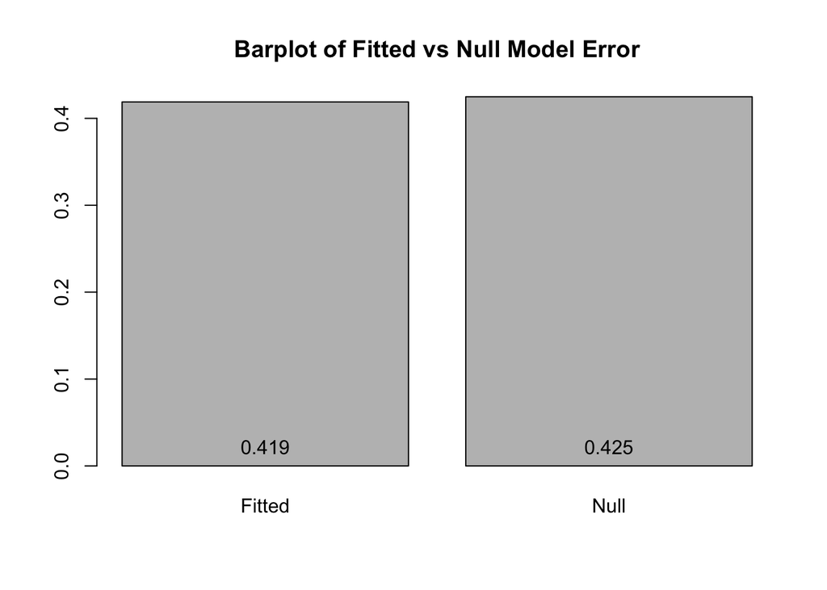

```r
bp <- barplot(df$error, names.arg = df$model, main = "Barplot of Fitted vs Null Model Error")
text(bp, 0, round(df$error, 3),cex=1,pos=3)
```

E:

Create indicator variables corresponding to dist < 100; dist between 100 and 200; and dist > 200. Fit a logistic regression for Pr(switch) using these indicators. With this new model, repeat the computations and graphs for part (a) of this exercise.

Create indicator variables and fit model:

```r
wells$less_100 <- ifelse(wells$dist < 100, 1, 0)
wells$greater_200 <- ifelse(wells$dist > 200, 1, 0)
wells$between <- ifelse(wells$dist < 200 & wells$dist > 100, 1, 0)

wells$less_100 <- as.factor(wells$less_100)
wells$greater_200 <- as.factor(wells$greater_200)
wells$between <- as.factor(wells$between)

fit_2 <- stan_glm(formula = switch ~ less_100 + greater_200 + between, family=binomial(link="logit"),
          data=wells)
```

Distance from well vs Pr(switch):

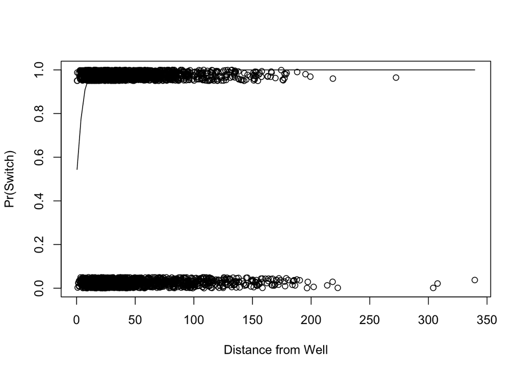

```r
#code from p 252 in text
jitter_binary <- function(a, jitt=0.05){
ifelse(a==0, runif(length(a), 0, jitt), runif(length(a), 1 - jitt, 1))
}

wells$switch_jitter <- jitter_binary(wells$switch)
plot(wells$dist, wells$switch_jitter, xlab = "Distance from Well", ylab = "Pr(Switch)")
curve(invlogit(coef(fit_2)[1] + coef(fit_2)[2]*x), add=TRUE)
```

Residual and Binned Plots:

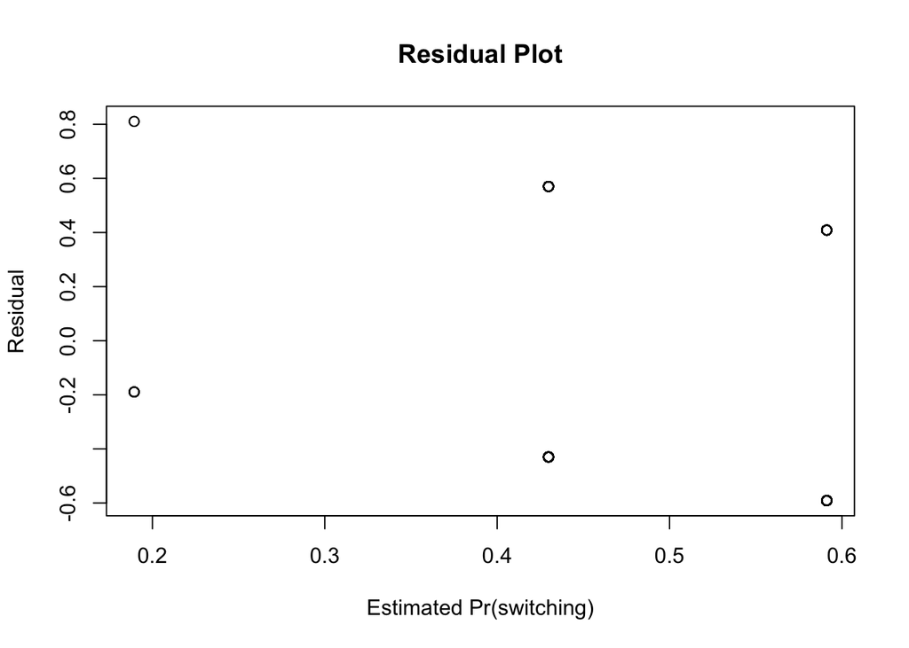

```r
#Residual plot
plot(fit_2$fitted.values, fit_2$residuals, main = "Residual Plot",
     xlab = "Estimated Pr(switching)", ylab = "Residual")
```

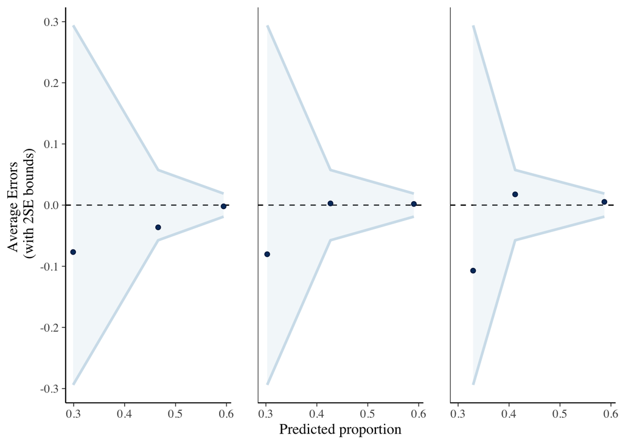

```r
#using rstanarm library
pp_check(fit_2, plotfun = "error_binned")
```

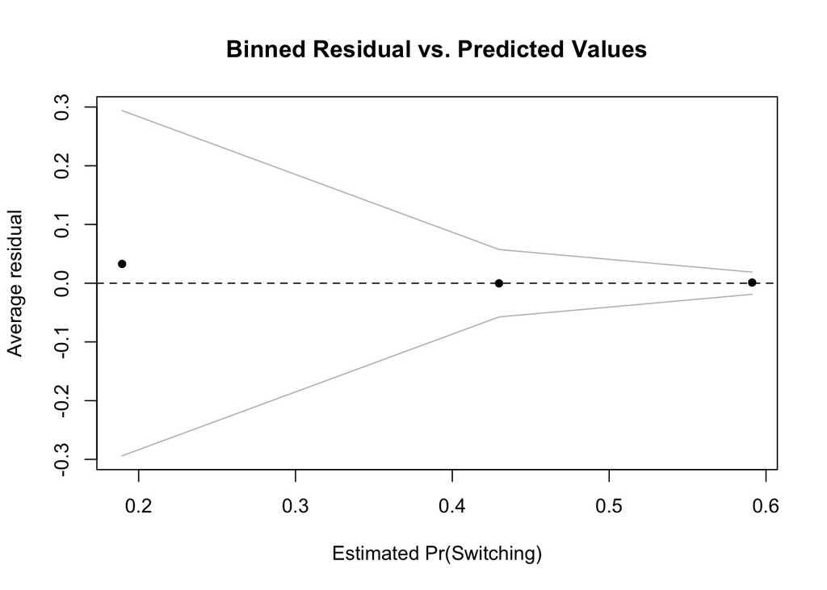

```r
#using arm (https://rdrr.io/cran/arm/man/binnedplot.html), more like book graph
arm::binnedplot(x = fit_2$fitted.values, fit_2$residuals,
                xlab = "Estimated Pr(Switching)",
                main = "Binned Residual vs. Predicted Values",
                col.int = "gray", nclass = 40)
```

Error rate calculation:

```r
#calculate predictions
wells$predicted_2 <- predict(fit_2, newdata = wells, type = "response")


#code from p 273 to compute error rate of models
error_rate_fit_2 <- mean((wells$predicted_2>0.5 & wells$switch==0) | (wells$predicted_2<0.5 & wells$switch==1))

#We can compare it to the error rate of the null model, which is simply to assign the same probability to each yi. This is simply logistic regression with only a constant term, and the estimated probability will simply be the proportion of 1’s in the data, or p = n i=1 yi/n (recalling that each yi = 0 or 1). The error rate of the null model is then p or 1−p, whichever is lower

prop_1_in_data <- table(wells$switch)

prop_1_in_data <- 1737/3020

error_rate_null <- 1 - prop_1_in_data

df2 <- data.frame(
  "model" <- c("Fitted", "Null"),
  "error" <- c(error_rate_fit_2, error_rate_null))

colnames(df2) <- c("model", "error")

print(paste("Fitted model error: ", round(error_rate_fit_2, 3)))
```

```
## [1] "Fitted model error:  0.409"
```

```r
print(paste("Null model error: ", round(error_rate_null, 3)))
```

```
## [1] "Null model error:  0.425"
```

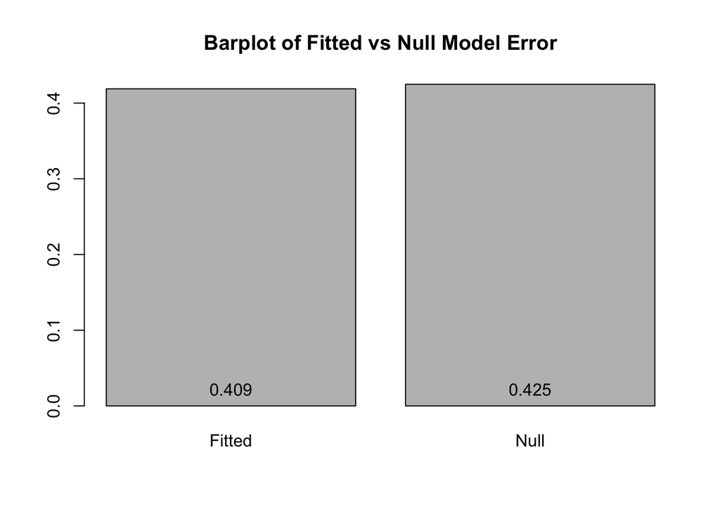

```r
bp <- barplot(df$error, names.arg = df2$model, main = "Barplot of Fitted vs Null Model Error")
text(bp, 0, round(df2$error, 3),cex=1,pos=3)
```